# Decision Tree in R

## Pima Indians Diabetes Prediction

This dataset is originally from the National Institute of Diabetes and Digestive and Kidney Diseases. The objective of the dataset is to diagnostically predict whether or not a patient has diabetes, based on certain diagnostic measurements included in the dataset. Several constraints were placed on the selection of these instances from a larger database. In particular, all patients here are females at least 21 years old of Pima Indian heritage.

### Data Exploration

First input and see the structure of the dataset:

```r
str(data_dib)
```

```
## 'data.frame':    768 obs. of  9 variables:
##  $ Pregnancies             : int  6 1 8 1 0 5 3 10 2 8 ...
##  $ Glucose                 : int  148 85 183 89 137 116 78 115 197 125 ...
##  $ BloodPressure           : int  72 66 64 66 40 74 50 0 70 96 ...
##  $ SkinThickness           : int  35 29 0 23 35 0 32 0 45 0 ...
##  $ Insulin                 : int  0 0 0 94 168 0 88 0 543 0 ...
##  $ BMI                     : num  33.6 26.6 23.3 28.1 43.1 25.6 31 35.3 30.5 0 ...
##  $ DiabetesPedigreeFunction: num  0.627 0.351 0.672 0.167 2.288 ...
##  $ Age                     : int  50 31 32 21 33 30 26 29 53 54 ...
##  $ Outcome                 : Factor w/ 2 levels "Negative","Positive": 2 1 2 1 2 1 2 1 2 2 ...
```

Summary about the dataset:

```r
summary(data_dib)
```

```
##   Pregnancies        Glucose      BloodPressure    SkinThickness
##  Min.   : 0.000   Min.   :  0.0   Min.   :  0.00   Min.   : 0.00
##  1st Qu.: 1.000   1st Qu.: 99.0   1st Qu.: 62.00   1st Qu.: 0.00
##  Median : 3.000   Median :117.0   Median : 72.00   Median :23.00
##  Mean   : 3.845   Mean   :120.9   Mean   : 69.11   Mean   :20.54
##  3rd Qu.: 6.000   3rd Qu.:140.2   3rd Qu.: 80.00   3rd Qu.:32.00
##  Max.   :17.000   Max.   :199.0   Max.   :122.00   Max.   :99.00
##     Insulin           BMI        DiabetesPedigreeFunction      Age
##  Min.   :  0.0   Min.   : 0.00   Min.   :0.0780           Min.   :21.00
##  1st Qu.:  0.0   1st Qu.:27.30   1st Qu.:0.2437           1st Qu.:24.00
##  Median : 30.5   Median :32.00   Median :0.3725           Median :29.00
##  Mean   : 79.8   Mean   :31.99   Mean   :0.4719           Mean   :33.24
##  3rd Qu.:127.2   3rd Qu.:36.60   3rd Qu.:0.6262           3rd Qu.:41.00
##  Max.   :846.0   Max.   :67.10   Max.   :2.4200           Max.   :81.00
##      Outcome
##  Negative:500
##  Positive:268
##
##
##
##
```

### The balace of prediction variable

```r
prop.table(table(data_dib$Outcome))
```

```
##
##  Negative  Positive
## 0.6510417 0.3489583
```

It is good that the dataset is not imbalance, around 65% and 35% for each type is an acceptable ratio.

### Missing values

Before check missing values of this dataset, follow the descript of this dataset “Missing values are believed to be encoded with zero values”, so it need to convert all zero values to NA before check missing values of this dataset:

```r
data_dib[data_dib == 0] <- NA
```

Plot the missing values:

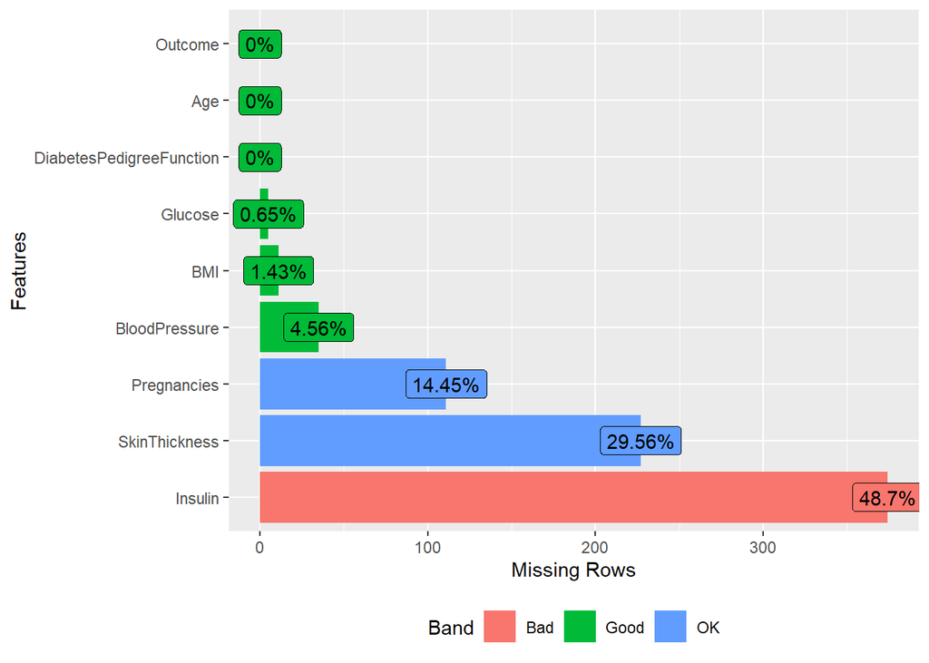

```r
plot_missing(data_dib)
```

```r
colSums(sapply(data_dib,is.na))
```

```
##              Pregnancies                  Glucose            BloodPressure
##                      111                        5                       35
##            SkinThickness                  Insulin                      BMI
##                      227                      374                       11
## DiabetesPedigreeFunction                      Age                  Outcome
##                        0                        0                        0
```

Top 3 variables have lot of missing values are Insulin (374 instances), Skin Thickness (227 instances), Pregnancies(111 instances)

### Imputation

Mice (Multivariate Imputation via Chained Equations) will be applied for imputation and check the missing value again:

```r
imputed_data <- mice(data_dib, method = 'pmm', seed = 123)
```

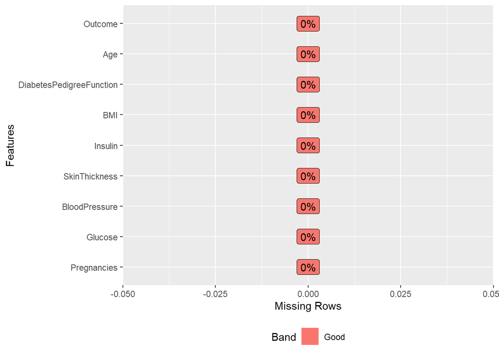

```r
data_dib_imp <- complete(imputed_data)
plot_missing(data_dib_imp)
```

Plot the distribution to compare the different before and after imputation of the Insulin variable:

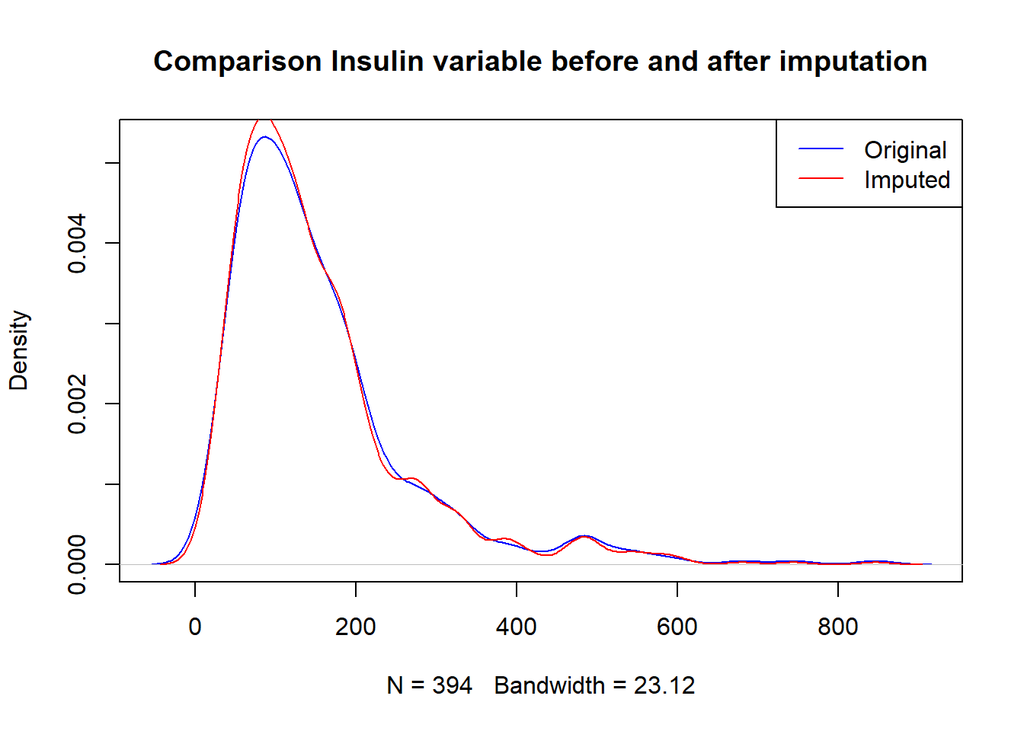

```r
plot(density(data_dib$Insulin, na.rm = TRUE), type="l", col="blue", main="Comparison Insulin variable before and after imputation")
lines(density(data_dib_imp$Insulin), type="l",  col="red")
legend("topright", legend=(c("Original","Imputed")), col=c("blue","red"), lty=1)
```

After the imputation the dataset still keep it original distribution.

### The correlation between each variable

```r
corrTable
```

```
##                          Pregnancies   Glucose BloodPressure SkinThickness
## Pregnancies               1.00000000 0.1549378   0.270510645     0.1783981
## Glucose                   0.15493779 1.0000000   0.229888320     0.2293780
## BloodPressure             0.27051064 0.2298883   1.000000000     0.2135024
## SkinThickness             0.17839812 0.2293780   0.213502433     1.0000000
## Insulin                   0.05221945 0.5737614   0.075311696     0.1455161
## BMI                       0.10342514 0.2414503   0.308815405     0.6601576
## DiabetesPedigreeFunction  0.01239013 0.1390211   0.005794758     0.1211303
## Age                       0.54904230 0.2705702   0.331659536     0.1790490
##                             Insulin        BMI DiabetesPedigreeFunction
## Pregnancies              0.05221945 0.10342514              0.012390130
## Glucose                  0.57376135 0.24145030              0.139021140
## BloodPressure            0.07531170 0.30881541              0.005794758
## SkinThickness            0.14551609 0.66015758              0.121130285
## Insulin                  1.00000000 0.21794749              0.112395444
## BMI                      0.21794749 1.00000000              0.151622010
## DiabetesPedigreeFunction 0.11239544 0.15162201              1.000000000
## Age                      0.18328640 0.03605588              0.033561312
##                                 Age
## Pregnancies              0.54904230
## Glucose                  0.27057020
## BloodPressure            0.33165954
## SkinThickness            0.17904903
## Insulin                  0.18328640
## BMI                      0.03605588
## DiabetesPedigreeFunction 0.03356131
## Age                      1.00000000
```

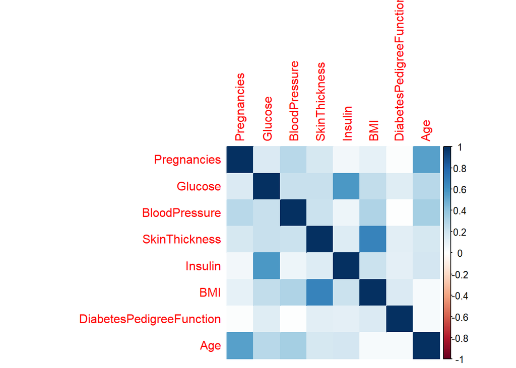

```r
corrplot(corrTable, method="color")
```

There are 3 pairs that have a moderate impact on each other: Pregnancies and Age, Glucose and Insulin, SkinThickness and BMI. So far, the dataset is ready for training and validation.

### Stratified sampling

The sampling will divide the dataset so that 70% instanses of the dataset will go for training and 30% will go for validating

```r
str(training_set)
```

```
## 'data.frame':    538 obs. of  9 variables:
##  $ Pregnancies             : int  6 1 1 6 10 8 4 10 10 5 ...
##  $ Glucose                 : int  148 85 89 137 115 125 110 168 139 166 ...
##  $ BloodPressure           : int  72 66 66 40 70 96 92 74 80 72 ...
##  $ SkinThickness           : int  35 29 23 35 31 32 32 37 41 19 ...
##  $ Insulin                 : int  210 36 94 168 94 205 57 180 29 175 ...
##  $ BMI                     : num  33.6 26.6 28.1 43.1 35.3 40.2 37.6 38 27.1 25.8 ...
##  $ DiabetesPedigreeFunction: num  0.627 0.351 0.167 2.288 0.134 ...
##  $ Age                     : int  50 31 21 33 29 54 30 34 57 51 ...
##  $ Outcome                 : Factor w/ 2 levels "Negative","Positive": 2 1 1 2 1 2 1 2 1 2 ...
```

```r
str(test_set)
```

```
## 'data.frame':    230 obs. of  9 variables:
##  $ Pregnancies             : int  8 5 3 2 1 13 1 1 3 8 ...
##  $ Glucose                 : int  183 116 78 197 189 118 103 115 126 99 ...
##  $ BloodPressure           : int  64 74 50 70 60 84 30 70 88 84 ...
##  $ SkinThickness           : int  17 23 32 45 23 47 38 30 41 32 ...
##  $ Insulin                 : int  465 110 88 543 846 230 83 96 235 175 ...
##  $ BMI                     : num  23.3 25.6 31 30.5 30.1 45.8 43.3 34.6 39.3 35.4 ...
##  $ DiabetesPedigreeFunction: num  0.672 0.201 0.248 0.158 0.398 0.551 0.183 0.529 0.704 0.388 ...
##  $ Age                     : int  32 30 26 53 59 31 33 32 27 50 ...
##  $ Outcome                 : Factor w/ 2 levels "Negative","Positive": 2 1 2 2 2 2 1 2 1 1 ...
```

The proportion of the target variable in training set and test set:

```r
prop.table(table(training_set$Outcome))
```

```
##
##  Negative  Positive
## 0.6505576 0.3494424
```

```r
prop.table(table(test_set$Outcome))
```

```
##
##  Negative  Positive
## 0.6521739 0.3478261
```

### Training with Default parameter Decision Tree

The data will go for training with default parament. For plotting the extra = 104 param mean each node will include the extra informations: fitted class, probability per class of observations in the node and percentages. The nn = True mean the node number will be included in each node.

```r
tree_def <- rpart(Outcome ~ ., data=training_set, method="class")
summary(tree_def)
```

```
## Call:
## rpart(formula = Outcome ~ ., data = training_set, method = "class")
##   n= 538
##
##           CP nsplit rel error    xerror       xstd
## 1 0.33510638      0 1.0000000 1.0000000 0.05882527
## 2 0.02925532      1 0.6648936 0.7287234 0.05375062
## 3 0.01950355      3 0.6063830 0.7287234 0.05375062
## 4 0.01861702      7 0.5159574 0.7606383 0.05450265
## 5 0.01595745      9 0.4787234 0.7606383 0.05450265
## 6 0.01063830     10 0.4627660 0.7659574 0.05462361
## 7 0.01000000     14 0.4148936 0.7765957 0.05486185
##
## Variable importance
##                  Glucose                      BMI                  Insulin
##                       42                       13                       13
##                      Age DiabetesPedigreeFunction            SkinThickness
##                        9                        7                        6
##              Pregnancies            BloodPressure
##                        5                        4
##
## Node number 1: 538 observations,    complexity param=0.3351064
##   predicted class=Negative  expected loss=0.3494424  P(node) =1
##     class counts:   350   188
##    probabilities: 0.651 0.349
##   left son=2 (409 obs) right son=3 (129 obs)
##   Primary splits:
##       Glucose     < 143.5  to the left,  improve=52.88214, (0 missing)
##       Insulin     < 111    to the left,  improve=32.10409, (0 missing)
##       BMI         < 29.55  to the left,  improve=25.03340, (0 missing)
##       Age         < 28.5   to the left,  improve=24.10181, (0 missing)
##       Pregnancies < 6.5    to the left,  improve=18.61768, (0 missing)
##   Surrogate splits:
##       Insulin                  < 222.5  to the left,  agree=0.810, adj=0.209, (0 split)
##       SkinThickness            < 53     to the left,  agree=0.766, adj=0.023, (0 split)
##       BMI                      < 47.35  to the left,  agree=0.766, adj=0.023, (0 split)
##       DiabetesPedigreeFunction < 1.934  to the left,  agree=0.764, adj=0.016, (0 split)
##       Age                      < 64.5   to the left,  agree=0.762, adj=0.008, (0 split)
##
## Node number 2: 409 observations,    complexity param=0.01950355
```

[output cut: 270 more lines]

```
##       Age                      < 28.5   to the left,  improve=1.8950850, (0 missing)
##       DiabetesPedigreeFunction < 0.4645 to the left,  improve=1.2907560, (0 missing)
##       Glucose                  < 106.5  to the left,  improve=0.8385918, (0 missing)
##       Insulin                  < 78     to the left,  improve=0.8385918, (0 missing)
##       Pregnancies              < 6.5    to the left,  improve=0.7669468, (0 missing)
##
## Node number 378: 7 observations
##   predicted class=Negative  expected loss=0.2857143  P(node) =0.01301115
##     class counts:     5     2
##    probabilities: 0.714 0.286
##
## Node number 379: 44 observations
##   predicted class=Positive  expected loss=0.3181818  P(node) =0.08178439
##     class counts:    14    30
##    probabilities: 0.318 0.682
```

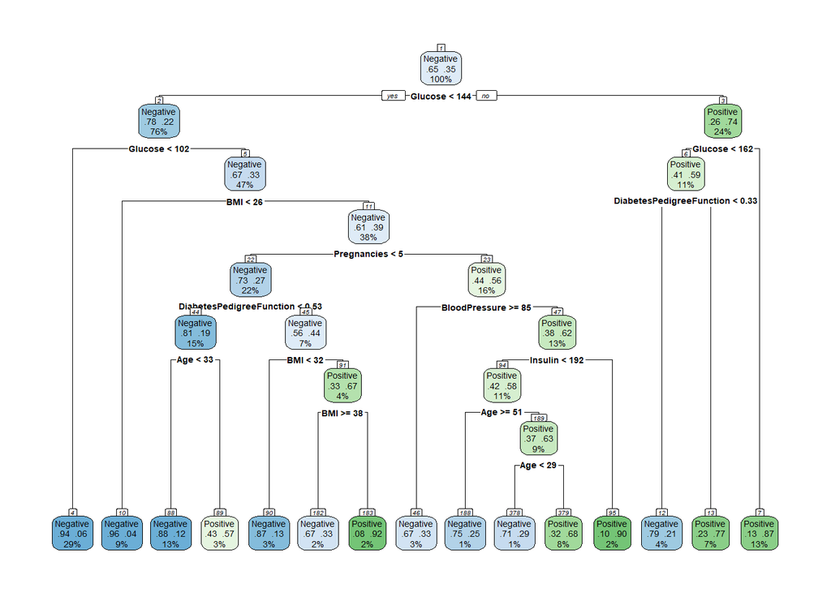

```r
rpart.plot(tree_def, extra = 104, nn = TRUE)
```

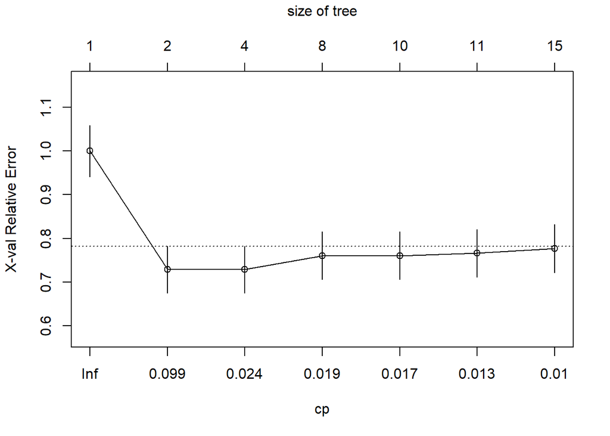

```r
plotcp(tree_def)
```

The complexity parameter from 0.019 getting stable.

### Training with Decision Tree using Information Gain index

Default the Decision Tree use Gini impurity measure to split the node, now using Information Gain impurity measure.

```r
tree_info <- rpart(Outcome ~ ., data=training_set, parms=list(split="information"))
summary(tree_info)
```

```
## Call:
## rpart(formula = Outcome ~ ., data = training_set, parms = list(split = "information"))
##   n= 538
##
##           CP nsplit rel error    xerror       xstd
## 1 0.33510638      0 1.0000000 1.0000000 0.05882527
## 2 0.02925532      1 0.6648936 0.7659574 0.05462361
## 3 0.01950355      3 0.6063830 0.7553191 0.05438045
## 4 0.01861702      6 0.5478723 0.7500000 0.05425701
## 5 0.01329787     10 0.4734043 0.7446809 0.05413231
## 6 0.01063830     13 0.4255319 0.6968085 0.05295218
## 7 0.01000000     15 0.4042553 0.7180851 0.05348973
##
## Variable importance
##                  Glucose                      BMI                  Insulin
##                       42                       13                       13
## DiabetesPedigreeFunction                      Age              Pregnancies
##                        9                        8                        6
##            SkinThickness            BloodPressure
##                        5                        4
##
## Node number 1: 538 observations,    complexity param=0.3351064
##   predicted class=Negative  expected loss=0.3494424  P(node) =1
##     class counts:   350   188
##    probabilities: 0.651 0.349
##   left son=2 (409 obs) right son=3 (129 obs)
##   Primary splits:
##       Glucose     < 143.5  to the left,  improve=56.75350, (0 missing)
##       Insulin     < 111    to the left,  improve=37.16906, (0 missing)
##       BMI         < 29.55  to the left,  improve=29.77275, (0 missing)
##       Age         < 28.5   to the left,  improve=27.23558, (0 missing)
##       Pregnancies < 6.5    to the left,  improve=19.73304, (0 missing)
##   Surrogate splits:
##       Insulin                  < 222.5  to the left,  agree=0.810, adj=0.209, (0 split)
##       SkinThickness            < 53     to the left,  agree=0.766, adj=0.023, (0 split)
##       BMI                      < 47.35  to the left,  agree=0.766, adj=0.023, (0 split)
##       DiabetesPedigreeFunction < 1.934  to the left,  agree=0.764, adj=0.016, (0 split)
##       Age                      < 64.5   to the left,  agree=0.762, adj=0.008, (0 split)
##
## Node number 2: 409 observations,    complexity param=0.01950355
```

[output cut: 295 more lines]

```
##       Glucose       < 104.5  to the left,  agree=0.750, adj=0.250, (0 split)
##       SkinThickness < 37.5   to the right, agree=0.750, adj=0.250, (0 split)
##       Insulin       < 86     to the left,  agree=0.750, adj=0.250, (0 split)
##       BloodPressure < 93     to the right, agree=0.708, adj=0.125, (0 split)
##       Age           < 28.5   to the left,  agree=0.708, adj=0.125, (0 split)
##
## Node number 746: 8 observations
##   predicted class=Negative  expected loss=0.375  P(node) =0.01486989
##     class counts:     5     3
##    probabilities: 0.625 0.375
##
## Node number 747: 16 observations
##   predicted class=Positive  expected loss=0.25  P(node) =0.02973978
##     class counts:     4    12
##    probabilities: 0.250 0.750
```

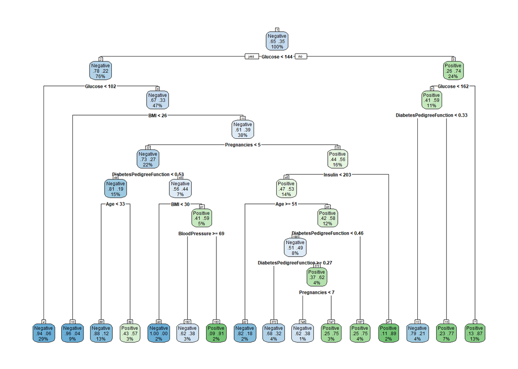

```r
rpart.plot(tree_info, extra = 104, nn = TRUE)
```

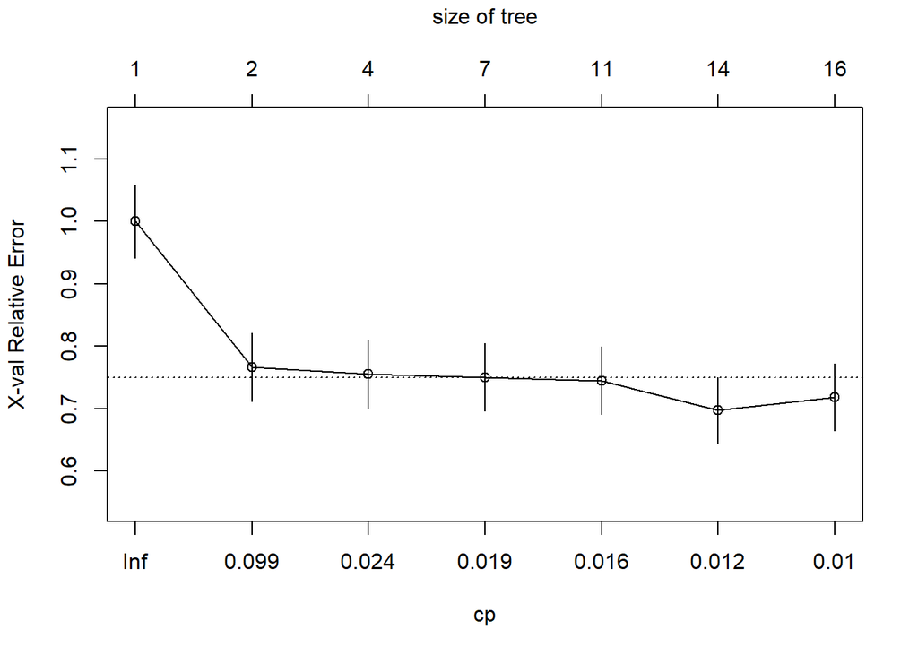

```r
plotcp(tree_info)
```

There is a little different in the Decision Tree, belong to the right son of node number 11, instead of Blood Pressure value is the split value, it change to Insulin. The complexity parameter plot from 0.019 it not stable anymore, the xerror now is fluctuate.

### Training with Decision Tree using Entropy index

```r
tree_entro <- rpart(Outcome ~ ., data=training_set, parms=list(split="entropy"))
summary(tree_entro)
```

```
## Call:
## rpart(formula = Outcome ~ ., data = training_set, parms = list(split = "entropy"))
##   n= 538
##
##           CP nsplit rel error    xerror       xstd
## 1 0.33510638      0 1.0000000 1.0000000 0.05882527
## 2 0.02925532      1 0.6648936 0.7287234 0.05375062
## 3 0.01950355      3 0.6063830 0.7393617 0.05400635
## 4 0.01861702      7 0.5159574 0.7127660 0.05335733
## 5 0.01595745      9 0.4787234 0.7180851 0.05348973
## 6 0.01063830     10 0.4627660 0.7074468 0.05322361
## 7 0.01000000     14 0.4148936 0.7127660 0.05335733
##
## Variable importance
##                  Glucose                      BMI                  Insulin
##                       42                       13                       13
##                      Age DiabetesPedigreeFunction            SkinThickness
##                        9                        7                        6
##              Pregnancies            BloodPressure
##                        5                        4
##
## Node number 1: 538 observations,    complexity param=0.3351064
##   predicted class=Negative  expected loss=0.3494424  P(node) =1
##     class counts:   350   188
##    probabilities: 0.651 0.349
##   left son=2 (409 obs) right son=3 (129 obs)
##   Primary splits:
##       Glucose     < 143.5  to the left,  improve=52.88214, (0 missing)
##       Insulin     < 111    to the left,  improve=32.10409, (0 missing)
##       BMI         < 29.55  to the left,  improve=25.03340, (0 missing)
##       Age         < 28.5   to the left,  improve=24.10181, (0 missing)
##       Pregnancies < 6.5    to the left,  improve=18.61768, (0 missing)
##   Surrogate splits:
##       Insulin                  < 222.5  to the left,  agree=0.810, adj=0.209, (0 split)
##       SkinThickness            < 53     to the left,  agree=0.766, adj=0.023, (0 split)
##       BMI                      < 47.35  to the left,  agree=0.766, adj=0.023, (0 split)
##       DiabetesPedigreeFunction < 1.934  to the left,  agree=0.764, adj=0.016, (0 split)
##       Age                      < 64.5   to the left,  agree=0.762, adj=0.008, (0 split)
##
## Node number 2: 409 observations,    complexity param=0.01950355
```

[output cut: 270 more lines]

```
##       Age                      < 28.5   to the left,  improve=1.8950850, (0 missing)
##       DiabetesPedigreeFunction < 0.4645 to the left,  improve=1.2907560, (0 missing)
##       Glucose                  < 106.5  to the left,  improve=0.8385918, (0 missing)
##       Insulin                  < 78     to the left,  improve=0.8385918, (0 missing)
##       Pregnancies              < 6.5    to the left,  improve=0.7669468, (0 missing)
##
## Node number 378: 7 observations
##   predicted class=Negative  expected loss=0.2857143  P(node) =0.01301115
##     class counts:     5     2
##    probabilities: 0.714 0.286
##
## Node number 379: 44 observations
##   predicted class=Positive  expected loss=0.3181818  P(node) =0.08178439
##     class counts:    14    30
##    probabilities: 0.318 0.682
```

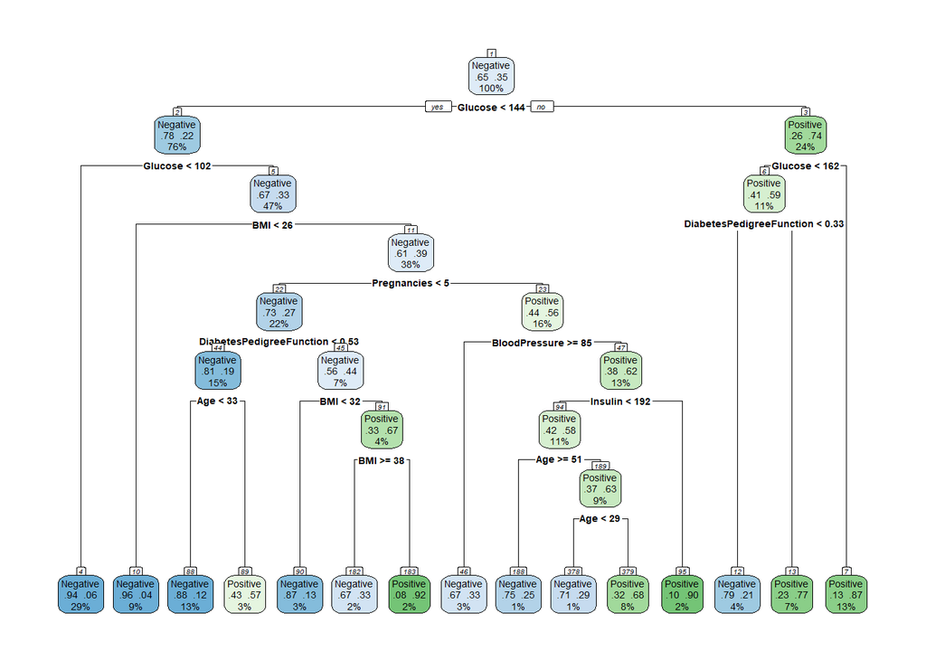

```r
rpart.plot(tree_entro, extra = 104, nn = TRUE)
```

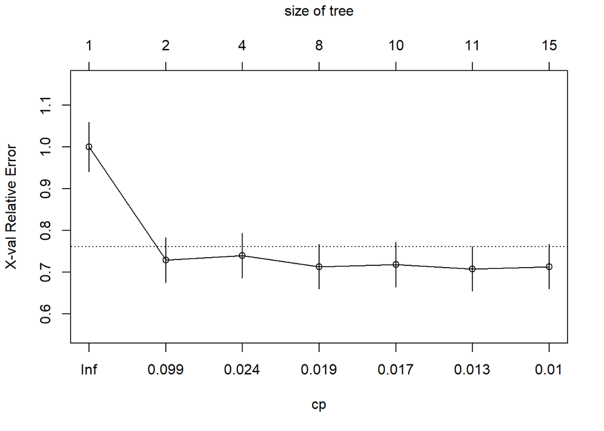

```r
plotcp(tree_entro)
```

The Decision Tree keep it same shape as using Gini index, while the complexity parameter plot is little different, but in general it starts stable from 0.019.

### Training with Parameter Decision Tree

We will using the Min bucket = 10, mean any leaf (terminal node) must have minimum 10 observation. Futhermore, as the complexity parameter plot show that from 0.019 the xerror already stable, the cp parameter will be apply to terminal when cp reach 0.019 to avoid overfitting.

```r
tree_param <- rpart(Outcome ~ ., data=training_set, minbucket = 10, cp = 0.019)
summary(tree_param)
```

```
## Call:
## rpart(formula = Outcome ~ ., data = training_set, minbucket = 10,
##     cp = 0.019)
##   n= 538
##
##           CP nsplit rel error    xerror       xstd
## 1 0.33510638      0 1.0000000 1.0000000 0.05882527
## 2 0.02925532      1 0.6648936 0.7606383 0.05450265
## 3 0.01950355      3 0.6063830 0.7393617 0.05400635
## 4 0.01900000      7 0.5159574 0.7340426 0.05387913
##
## Variable importance
##                  Glucose                  Insulin                      BMI
##                       51                       13                       11
##              Pregnancies DiabetesPedigreeFunction            SkinThickness
##                        6                        6                        4
##                      Age            BloodPressure
##                        4                        3
##
## Node number 1: 538 observations,    complexity param=0.3351064
##   predicted class=Negative  expected loss=0.3494424  P(node) =1
##     class counts:   350   188
##    probabilities: 0.651 0.349
##   left son=2 (409 obs) right son=3 (129 obs)
##   Primary splits:
##       Glucose     < 143.5  to the left,  improve=52.88214, (0 missing)
##       Insulin     < 111    to the left,  improve=32.10409, (0 missing)
##       BMI         < 29.55  to the left,  improve=25.03340, (0 missing)
##       Age         < 28.5   to the left,  improve=24.10181, (0 missing)
##       Pregnancies < 6.5    to the left,  improve=18.61768, (0 missing)
##   Surrogate splits:
##       Insulin                  < 222.5  to the left,  agree=0.810, adj=0.209, (0 split)
##       SkinThickness            < 53     to the left,  agree=0.766, adj=0.023, (0 split)
##       BMI                      < 47.35  to the left,  agree=0.766, adj=0.023, (0 split)
##       DiabetesPedigreeFunction < 1.934  to the left,  agree=0.764, adj=0.016, (0 split)
##       Age                      < 64.5   to the left,  agree=0.762, adj=0.008, (0 split)
##
## Node number 2: 409 observations,    complexity param=0.01950355
##   predicted class=Negative  expected loss=0.2249389  P(node) =0.760223
##     class counts:   317    92
```

[output cut: 122 more lines]

```
##       Glucose                  < 106.5  to the left,  improve=1.379477, (0 missing)
##   Surrogate splits:
##       SkinThickness < 20     to the left,  agree=0.805, adj=0.056, (0 split)
##       BMI           < 43.2   to the right, agree=0.805, adj=0.056, (0 split)
##       Age           < 63.5   to the right, agree=0.805, adj=0.056, (0 split)
##
## Node number 46: 18 observations
##   predicted class=Negative  expected loss=0.3333333  P(node) =0.03345725
##     class counts:    12     6
##    probabilities: 0.667 0.333
##
## Node number 47: 69 observations
##   predicted class=Positive  expected loss=0.3768116  P(node) =0.1282528
##     class counts:    26    43
##    probabilities: 0.377 0.623
```

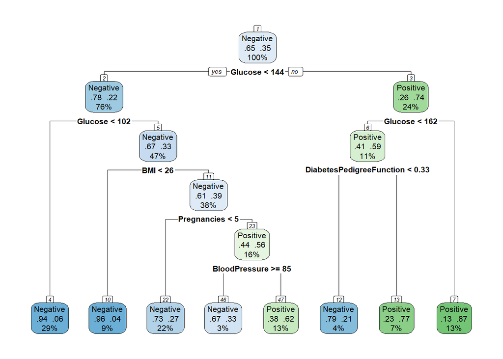

```r
rpart.plot(tree_param, extra = 104, nn = TRUE)
```

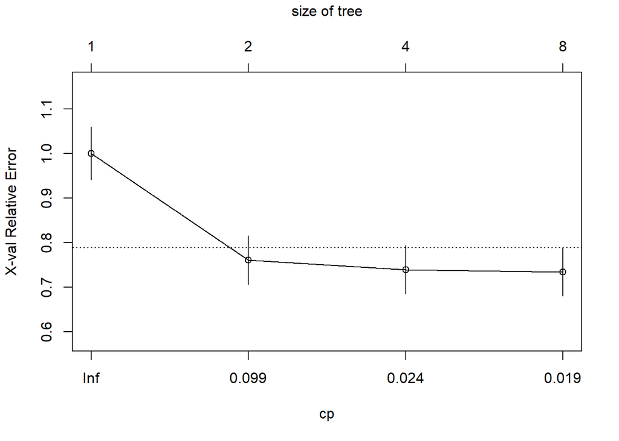

```r
plotcp(tree_param)
```

The Decision Tree now look simpler than above.

### Preditction Result

Predict the 4 models above on the test set and training set:

```r
predict_def_test = predict(tree_def, test_set, type = "class")
predict_def_train = predict(tree_def, training_set, type = "class")
predict_info_test = predict(tree_info, test_set, type = "class")
predict_info_train = predict(tree_info, training_set, type = "class")
predict_entro_test = predict(tree_entro, test_set, type = "class")
predict_entro_train = predict(tree_entro, training_set, type = "class")
predict_param_test = predict(tree_param, test_set, type = "class")
predict_param_train = predict(tree_param, training_set, type = "class")
#Confusion Matrix
cm_def_test = table(predict_def_test, test_set$Outcome)
cm_def_train = table(predict_def_train, training_set$Outcome)
cm_info_test = table(predict_info_test, test_set$Outcome)
cm_info_train = table(predict_info_train, training_set$Outcome)
cm_entro_test = table(predict_entro_test, test_set$Outcome)
cm_entro_train = table(predict_entro_train, training_set$Outcome)
cm_param_test = table(predict_param_test, test_set$Outcome)
cm_param_train = table(predict_param_train, training_set$Outcome)
```

Confusion Matrix of the prediction above:

```r
cm_def_test
```

```
##
## predict_def_test Negative Positive
##         Negative      118       38
##         Positive       32       42
```

```r
cm_def_train
```

```
##
## predict_def_train Negative Positive
##          Negative      310       38
##          Positive       40      150
```

```r
cm_info_test
```

```
##
## predict_info_test Negative Positive
##          Negative      116       37
##          Positive       34       43
```

```r
cm_info_train
```

```
##
## predict_info_train Negative Positive
##           Negative      314       40
##           Positive       36      148
```

```r
cm_entro_test
```

```
##
## predict_entro_test Negative Positive
##           Negative      118       38
##           Positive       32       42
```

```r
cm_entro_train
```

```
##
## predict_entro_train Negative Positive
##            Negative      310       38
##            Positive       40      150
```

```r
cm_param_test
```

```
##
## predict_param_test Negative Positive
##           Negative      125       43
##           Positive       25       37
```

```r
cm_param_train
```

```
##
## predict_param_train Negative Positive
##            Negative      306       53
##            Positive       44      135
```

The prediction accuracy of the 4 models above on the training and test set:

| Default Parameter Decision Tree Accuracy on training set | Default Parameter Decision Tree Accuracy on test set | Decision Tree using Information Gain index Accuracy on training set | Decision Tree using Information Gain index Accuracy on test set | Decision Tree using Entropy index Accuracy on training set | Decision Tree using Entropy index Accuracy on test set | Parameter Decision Tree Accuracy on training set | Parameter Decision Tree Accuracy on test set |
| --- | --- | --- | --- | --- | --- | --- | --- |
| 0.8550186 | 0.6956522 | 0.8587361 | 0.6913043 | 0.8550186 | 0.6956522 | 0.8197026 | 0.7043478 |

The Parameter Decision Tree with highest accuracy although just slightly, it may overcome the overfitting ib the training set as the first 3 models have very high accuaracy value on training set.

The ROC curve of 4 models on test set, note that the curves of Default Parameter Decision Tree and Decision Tree using Entropy index have overlap each other as they have same feature.

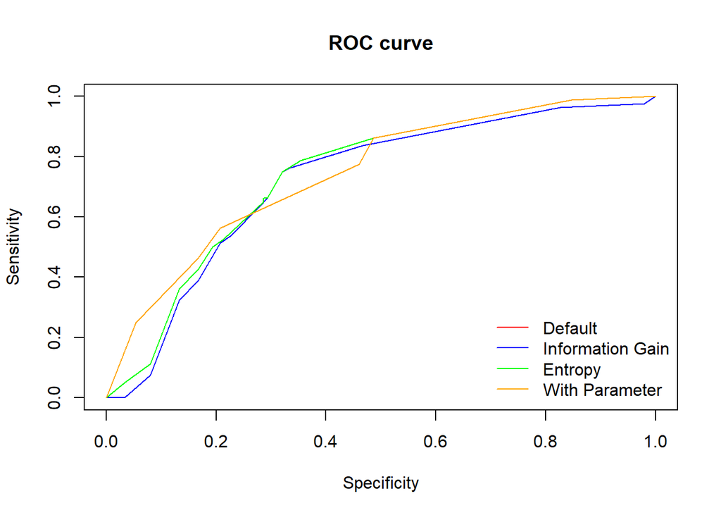

```r
plot(perf_def,
     main = "ROC curve",
     ylab = "Sensitivity",
     xlab = "Specificity", col = "red")
plot(perf_info, add = TRUE, col = "blue")
plot(perf_entro, add = TRUE, col = "green")
plot(perf_param, add = TRUE, col = "orange")
legend("bottomright", c("Default", "Information Gain", "Entropy", "With Parameter"), lty=1,
    col = c("red", "blue","green","orange"), bty="n")
```

The AUC summary table of 4 models:

| Default Parameter Decision Tree | Decision Tree using Information Gain index | Decision Tree using Entropy index | Parameter Decision Tree |
| --- | --- | --- | --- |
| 0.74 | 0.721 | 0.74 | 0.744 |

The AUC of Decision Tree using Information Gain index reach the lowest among 4 models. Default Decision Tree, Decision Tree using Entropy index, Parameter Decision Tree share the similarity AUC value.

### Naïve Bayes Result

Conduct an experiment with Naïve Bayes on test set, in order to compare Decision Tree with other classification:

```r
classifier_def = naive_bayes(x = training_set[ ,-9], y = training_set$Outcome )
classifier_lap = naive_bayes(x = training_set[ ,-9], y = training_set$Outcome,laplace = 1 )
classifier_kernel = naive_bayes(x = training_set[ ,-9], y = training_set$Outcome, usekernel = TRUE )
#Predicting
pred_nb_def <- predict(classifier_def, newdata = test_set[ ,-9])
cm_nb_def <- table(test_set$Outcome, pred_nb_def)
accuracy_nb_def <- sum(diag(cm_nb_def))/sum(cm_nb_def)

pred_nb_lap <- predict(classifier_lap, newdata = test_set[ ,-9])
cm_nb_lap <- table(test_set$Outcome, pred_nb_lap)
accuracy_nb_lap <- sum(diag(cm_nb_lap))/sum(cm_nb_lap)

pred_nb_kernel <- predict(classifier_kernel, newdata = test_set[ ,-9])
cm_nb_kernel <- table(test_set$Outcome, pred_nb_kernel)
accuracy_nb_kernel <- sum(diag(cm_nb_kernel))/sum(cm_nb_kernel)
```

The accuracy of 3 models based on Naive Bayes:

| Default Naïve Bayes | Naïve Bayes using Laplace | Naïve Bayes using Kernel |
| --- | --- | --- |
| 0.7652174 | 0.7652174 | 0.7913043 |

### Conclusion

Among 4 models based on Decision Tree, Parameter Decision Tree model, which limit the complexity at 0.019 show the best performance. But in the final, the best model show it highest accuracy is Naïve Bayes using Kernel.